# Enjoy Mushrooms!

## Data Exploration

Let's start by importing these libraries.

```python
import pandas as pd
import numpy as np
import seaborn as sns
import matplotlib.pyplot as plt
%matplotlib inline
import os
import numpy
```

Then, we have to read the data file in which the dataset is stored. In adittion, we are going to see the main information about it and about the features of the dataset.

```python
df = pd.read_csv('./mushrooms.csv')
print('Dataset Information: \n')
print(df.info())
```

```
Dataset Information:

<class 'pandas.core.frame.DataFrame'>
RangeIndex: 8124 entries, 0 to 8123
Data columns (total 23 columns):
class                       8124 non-null object
cap-shape                   8124 non-null object
cap-surface                 8124 non-null object
cap-color                   8124 non-null object
bruises                     8124 non-null object
odor                        8124 non-null object
gill-attachment             8124 non-null object
gill-spacing                8124 non-null object
gill-size                   8124 non-null object
gill-color                  8124 non-null object
stalk-shape                 8124 non-null object
stalk-root                  8124 non-null object
stalk-surface-above-ring    8124 non-null object
stalk-surface-below-ring    8124 non-null object
stalk-color-above-ring      8124 non-null object
stalk-color-below-ring      8124 non-null object
veil-type                   8124 non-null object
veil-color                  8124 non-null object
ring-number                 8124 non-null object
ring-type                   8124 non-null object
spore-print-color           8124 non-null object
population                  8124 non-null object
habitat                     8124 non-null object
dtypes: object(23)
memory usage: 1.4+ MB
None
```

As we can see, we have a Pandas Dataframe with 8124 records ranging from 0 to 8123. It has 23 features and all of them are non-null objects. These features are nominal features and can be defined as followed:

- #### class: Mushroom is edible or poisonous.
- #### cap-shape: Shape of cap.
- #### cap-surface: Touch of the mushroom surface.
- #### cap-color: Cap color.
- #### bruises: Has bruises or not.
- #### odor: Odor of the mushroom.
- #### gill-attachment: Type of gill.
- #### gill-spacing: Spacing among gills.
- #### gill-size: Gill size.
- #### gill-color: Gill color.
- #### stalk-shape: Stalk shape.
- #### stalk-root: Root stalk.
- #### stalk-surface-above-ring: Ring above stalk surface.
- #### stalk-surface-below-ring: Ring below stalk surface.
- #### stalk-color-above-ring: Ring above stalk color.
- #### stalk-color-below-ring: Stalk color below ring.
- #### veil-type: Veil type.
- #### veil-color: Veil color.
- #### ring-number: Ring number.
- #### ring-type: Ring type.
- #### spore-print-color: Spore print color.
- #### population: Size of population.
- #### habitat: Habitat where it lives.

```python
df.head()
```

|  | class | cap-shape | cap-surface | cap-color | bruises | odor | gill-attachment | gill-spacing | gill-size | gill-color | ... | stalk-surface-below-ring | stalk-color-above-ring | stalk-color-below-ring | veil-type | veil-color | ring-number | ring-type | spore-print-color | population | habitat |
| --- | --- | --- | --- | --- | --- | --- | --- | --- | --- | --- | --- | --- | --- | --- | --- | --- | --- | --- | --- | --- | --- |
| 0 | p | x | s | n | t | p | f | c | n | k | ... | s | w | w | p | w | o | p | k | s | u |
| 1 | e | x | s | y | t | a | f | c | b | k | ... | s | w | w | p | w | o | p | n | n | g |
| 2 | e | b | s | w | t | l | f | c | b | n | ... | s | w | w | p | w | o | p | n | n | m |
| 3 | p | x | y | w | t | p | f | c | n | n | ... | s | w | w | p | w | o | p | k | s | u |
| 4 | e | x | s | g | f | n | f | w | b | k | ... | s | w | w | p | w | o | e | n | a | g |

5 rows × 23 columns

Although we have checked that all of them are non-null objects, let's see if that is true:

```python
# HAY VALORES NULOS? RESPUESTA: NO
print(df.isnull().sum().sort_values(ascending=False))
```

```
habitat                     0
stalk-shape                 0
cap-shape                   0
cap-surface                 0
cap-color                   0
bruises                     0
odor                        0
gill-attachment             0
gill-spacing                0
gill-size                   0
gill-color                  0
stalk-root                  0
population                  0
stalk-surface-above-ring    0
stalk-surface-below-ring    0
stalk-color-above-ring      0
stalk-color-below-ring      0
veil-type                   0
veil-color                  0
ring-number                 0
ring-type                   0
spore-print-color           0
class                       0
dtype: int64
```

Once more we have verified that there are no null values in our dataset. Now, we are going to see the total number of different values for each feature and the value itself.

```python
# CUANTOS VALORES UNICOS HAY POR CADA ATRIBUTO? CUALES SON?

print('Unique Class: ' + str(df['class'].nunique()) + ' -> ' +str(df['class'].unique()) + '\n')
print('Unique Cap-Shape: ' + str(df['cap-shape'].nunique()) + ' -> ' +str(df['cap-shape'].unique()) + '\n')
print('Unique Cap-Surface: ' + str(df['cap-surface'].nunique()) + ' -> ' +str(df['cap-surface'].unique()) + '\n')
print('Unique Cap-Color: ' + str(df['cap-color'].nunique()) + ' -> ' +str(df['cap-color'].unique()) + '\n')
print('Unique Bruises: ' + str(df['bruises'].nunique()) + ' -> ' +str(df['bruises'].unique()) + '\n')
print('Unique Odor: ' + str(df['odor'].nunique()) + ' -> ' +str(df['odor'].unique()) + '\n')
print('Unique Gill-Attachment: ' + str(df['gill-attachment'].nunique()) + ' -> ' +str(df['gill-attachment'].unique()) + '\n')
print('Unique Gill-Spacing: ' + str(df['gill-spacing'].nunique()) + ' -> ' +str(df['gill-spacing'].unique()) + '\n')
print('Unique Gill-Size: ' + str(df['gill-size'].nunique()) + ' -> ' +str(df['gill-size'].unique()) + '\n')
print('Unique Gill-Color: ' + str(df['gill-color'].nunique()) + ' -> ' +str(df['gill-color'].unique()) + '\n')
print('Unique Stalk-Shape: ' + str(df['stalk-shape'].nunique()) + ' -> ' +str(df['stalk-shape'].unique()) + '\n')
print('Unique Stalk-Root: ' + str(df['stalk-root'].nunique()) + ' -> ' +str(df['stalk-root'].unique()) + '\n')
print('Unique Stalk-Surface-Above-Ring: ' + str(df['stalk-surface-above-ring'].nunique()) + ' -> ' +str(df['stalk-surface-above-ring'].unique()) + '\n')
print('Unique Stalk-Surface-Below-Ring: ' + str(df['stalk-surface-below-ring'].nunique()) + ' -> ' +str(df['stalk-surface-below-ring'].unique()) + '\n')
print('Unique Stalk-Color-Above-Ring: ' + str(df['stalk-color-above-ring'].nunique()) + ' -> ' +str(df['stalk-color-above-ring'].unique()) + '\n')
print('Unique Stalk-Color-Below-Ring: ' + str(df['stalk-color-below-ring'].nunique()) + ' -> ' +str(df['stalk-color-below-ring'].unique()) + '\n')
print('Unique Veil-Type: ' + str(df['veil-type'].nunique()) + ' -> ' +str(df['veil-type'].unique()) + '\n')
print('Unique Veil-Color: ' + str(df['veil-color'].nunique()) + ' -> ' +str(df['veil-color'].unique()) + '\n')
print('Unique Ring-Number: ' + str(df['ring-number'].nunique()) + ' -> ' +str(df['ring-number'].unique()) + '\n')
print('Unique Ring-Type: ' + str(df['ring-type'].nunique()) + ' -> ' +str(df['ring-type'].unique()) + '\n')
print('Unique Spore-Print-Color: ' + str(df['spore-print-color'].nunique()) + ' -> ' +str(df['spore-print-color'].unique()) + '\n')
print('Unique Population: ' + str(df['population'].nunique()) + ' -> ' +str(df['population'].unique()) + '\n')
print('Unique Habitat: ' + str(df['habitat'].nunique()) + ' -> ' +str(df['habitat'].unique()) + '\n')
```

```
Unique Class: 2 -> ['p' 'e']

Unique Cap-Shape: 6 -> ['x' 'b' 's' 'f' 'k' 'c']

Unique Cap-Surface: 4 -> ['s' 'y' 'f' 'g']

Unique Cap-Color: 10 -> ['n' 'y' 'w' 'g' 'e' 'p' 'b' 'u' 'c' 'r']

Unique Bruises: 2 -> ['t' 'f']

Unique Odor: 9 -> ['p' 'a' 'l' 'n' 'f' 'c' 'y' 's' 'm']

Unique Gill-Attachment: 2 -> ['f' 'a']

Unique Gill-Spacing: 2 -> ['c' 'w']

Unique Gill-Size: 2 -> ['n' 'b']

Unique Gill-Color: 12 -> ['k' 'n' 'g' 'p' 'w' 'h' 'u' 'e' 'b' 'r' 'y' 'o']

Unique Stalk-Shape: 2 -> ['e' 't']

Unique Stalk-Root: 5 -> ['e' 'c' 'b' 'r' '?']

Unique Stalk-Surface-Above-Ring: 4 -> ['s' 'f' 'k' 'y']

Unique Stalk-Surface-Below-Ring: 4 -> ['s' 'f' 'y' 'k']

Unique Stalk-Color-Above-Ring: 9 -> ['w' 'g' 'p' 'n' 'b' 'e' 'o' 'c' 'y']

Unique Stalk-Color-Below-Ring: 9 -> ['w' 'p' 'g' 'b' 'n' 'e' 'y' 'o' 'c']

Unique Veil-Type: 1 -> ['p']

Unique Veil-Color: 4 -> ['w' 'n' 'o' 'y']

Unique Ring-Number: 3 -> ['o' 't' 'n']

Unique Ring-Type: 5 -> ['p' 'e' 'l' 'f' 'n']

Unique Spore-Print-Color: 9 -> ['k' 'n' 'u' 'h' 'w' 'r' 'o' 'y' 'b']

Unique Population: 6 -> ['s' 'n' 'a' 'v' 'y' 'c']

Unique Habitat: 7 -> ['u' 'g' 'm' 'd' 'p' 'w' 'l']
```

## Data Cleaning

We see that the Stalk-Root variable can take the value '?' which doesn't provide us with anything meaningful. Therefore, we are going to remove it from the dataset so that at the same time we are deleting outliers.

To do that, we are going to substitute '?' values for NaN values.

```python
# HAY UN VALOR '?' EN EL CAMPO STALK-ROOT QUE NO APORTA NINGUNA INFO, POR TANTO,
# ELIMINAMOS LAS INSTANCIAS QUE LO CONTENGAN
df = df.replace('?', numpy.NaN)
print(df['stalk-root'])
```

```
0         e
1         c
2         c
3         e
4         e
5         c
6         c
7         c
8         e
9         c
10        c
11        c
12        c
13        e
14        e
```

[output cut: 47 more lines]

```python
# DELETING...
df.dropna(inplace=True)
print(df.shape)
```

```
(5644, 23)
```

The number of instances in our dataset has decreased, which is normal, however, we have now our dataset clean.

## Data Visualization

```python
# NOW THE DATASET HAS NO MISSING VALUES NOR NULL VALUES.

# --------------------- DATASET CLEAN. ------------------------

# ¿HOW MANY ARE EDIBLE AND HOW MANY POISONOUS?
pd.value_counts(df['class'])
```

```
e    3488
p    2156
Name: class, dtype: int64
```

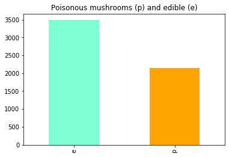

```python
df['class'].value_counts().plot(kind='bar', title='Poisonous mushrooms (p) and edible (e)', color=['aquamarine','orange'])
```

The distribution between poisonous and edible mushrooms is not balanced in the dataset.

Next, we are going to see the distribution of the different features with regards to the variable 'class' which is the one that tells us if a mushrooms is ('e') or not edible ('p').

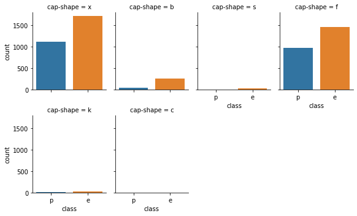

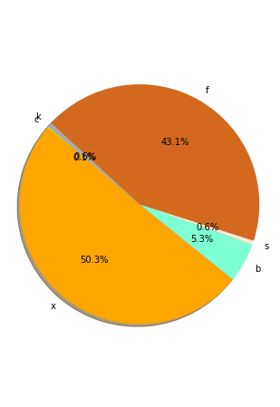

```python
get_plots('cap-shape');get_pie_chart(1,2)
```

Looking at these grahps we can draw several conclusions: We can point out that in the case of the variable 'cap-shape' most or the records in the dataset take the value of convex ('x') or flat ('f'). 50.3% in the first case and 43.1% in the second one. In addition, deepening in these variables, we can see that when the variable took the value 'x', most of them are edible. And the same happens when this variable is flat.

We'll do this kind of analysis for all the features.

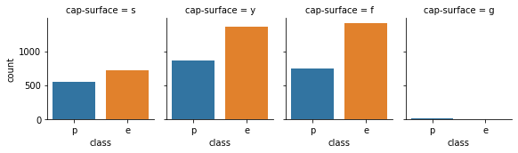

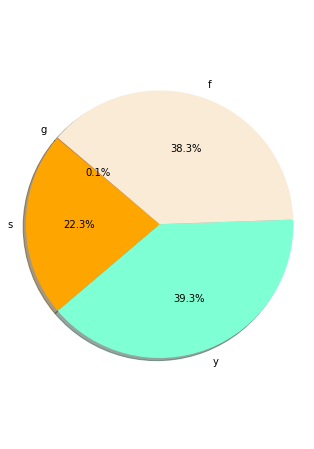

```python
get_plots('cap-surface');get_pie_chart(2,3)
```

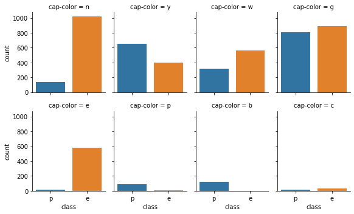

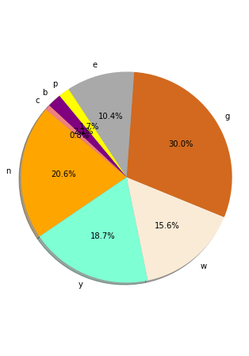

```python
get_plots('cap-color');get_pie_chart(3,4)
```

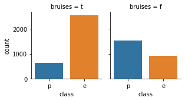

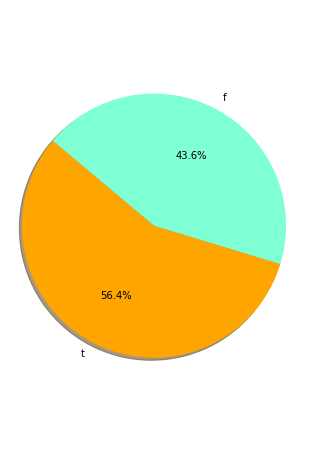

```python
get_plots('bruises');get_pie_chart(4,5)
```

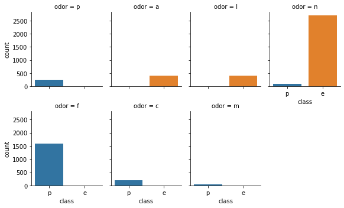

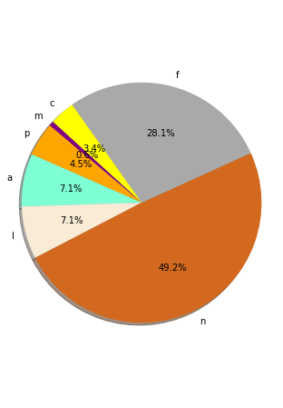

```python
get_plots('odor');get_pie_chart(5,6)
```

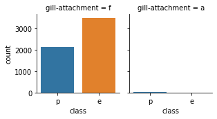

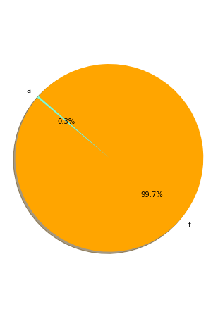

```python
get_plots('gill-attachment');get_pie_chart(6,7)
```

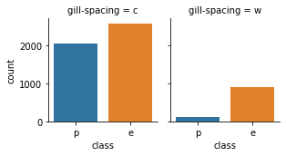

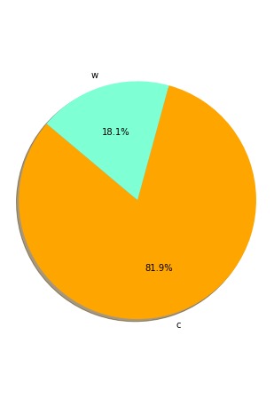

```python
get_plots('gill-spacing');get_pie_chart(7,8)
```

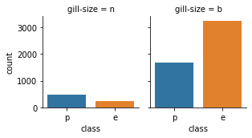

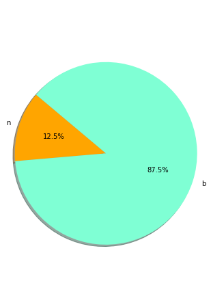

```python
get_plots('gill-size');get_pie_chart(8,9)
```

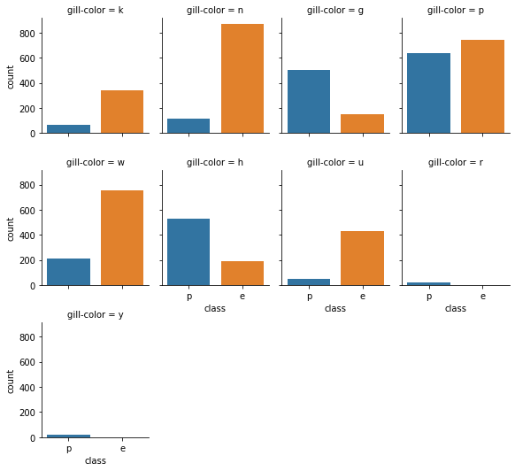

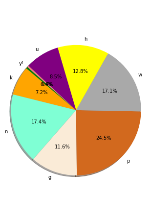

```python
get_plots('gill-color');get_pie_chart(9,10)
```

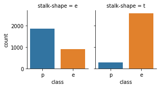

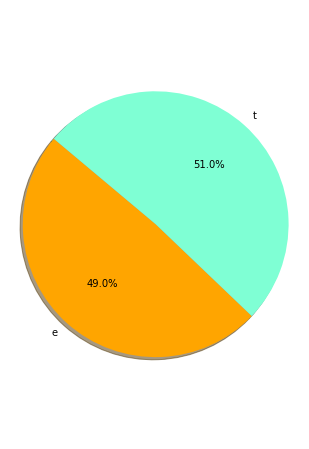

```python
get_plots('stalk-shape');get_pie_chart(10,11)
```

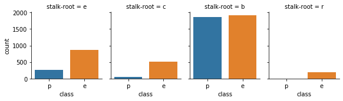

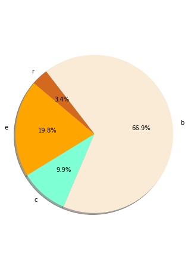

```python
get_plots('stalk-root');get_pie_chart(11,12)
```

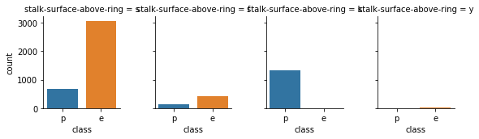

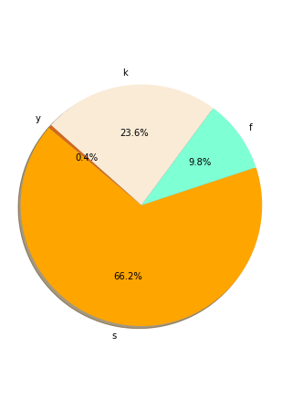

```python
get_plots('stalk-surface-above-ring');get_pie_chart(12,13)
```

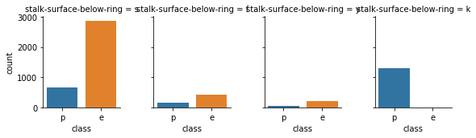

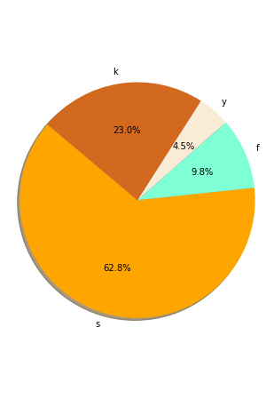

```python
get_plots('stalk-surface-below-ring');get_pie_chart(13,14)
```

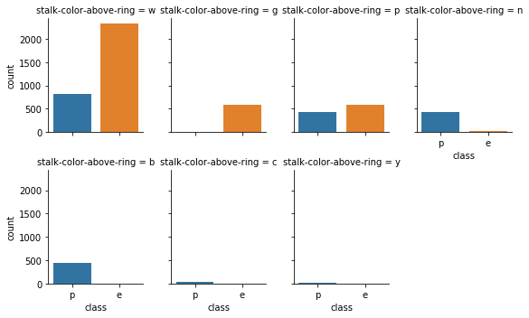

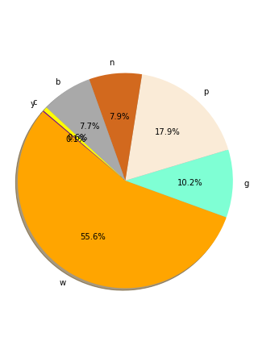

```python
get_plots('stalk-color-above-ring');get_pie_chart(14,15)
```

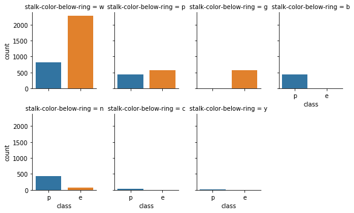

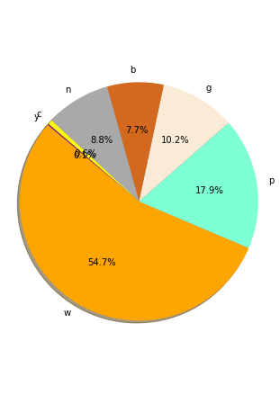

```python
get_plots('stalk-color-below-ring');get_pie_chart(15,16)
```